# Objective 3

2025-10-09

# CHAPTER 1: Introduction

## 1.0 Overview

The spatial pattern of fire incidents is a critical area of study, particularly in urban environments where population density and infrastructure can significantly influence fire dynamics. This research project focuses on the spatial distribution of fire incidents in Washington, D.C., Maryland, and Virginia, examining how geographic and environmental factors contribute to the occurrence and frequency of fires.

## 1.1 Objectives

Analyze the spatial distribution of fire incidents across Washington, D.C., Maryland, and Virginia, identifying geographic hotspots and patterns in urban versus rural areas. Investigate the role of environmental factors, such as weather conditions and vegetation, in influencing the incidence of fires in the studied regions during 2018. Categorize types of fire incidents (e.g., residential, commercial, vehicle) and assess their causes, comparing urban and rural settings to identify specific risk factors.

## 1.2 Research Questions

What geographic patterns can be identified in the distribution of fire incidents across Washington, D.C., Maryland, and Virginia in 2018?

How do environmental factors influence the incidence of fires in the studied regions during 2018?

What types of fire incidents were most prevalent, and what are the specific causes associated with these incidents in both urban and rural settings?

## 1.3 Significance of the Study

This project study enhances understanding of fire incident dynamics in Washington, D.C., Maryland, and Virginia. Findings can inform policymakers and emergency services about high-risk areas and the underlying causes of fires, facilitating targeted prevention strategies and improving public safety initiatives.

# CHAPTER 2: Methodology

## 2.0 Dataset

spatial data for project study area (DC,MD AND VA) were downloaded from Diva GIS (https://diva-gis.org/data.html)

## 2.1 Software

The following software was used for this project:

R and R Markdown GitHub (GitHub Repository) Microsoft Excel

# Objective 3: Categorize Types of Fire Incidents and Assess Causes

# Read dataset

```r
fire <- read.csv("Fire incidences DC_VA_MD_cleands.csv")
```

# Quick overview

```r
str(fire)
```

```
## 'data.frame':    8276 obs. of  18 variables:
##  $ OBJECTID                  : num  3475 3483 3505 3506 3514 ...
##  $ SOURCE_SYSTEM_TYPE        : chr  "FED" "FED" "FED" "FED" ...
##  $ SOURCE_SYSTEM             : chr  "FS-FIRESTAT" "FS-FIRESTAT" "FS-FIRESTAT" "FS-FIRESTAT" ...
##  $ NWCG_REPORTING_UNIT_NAME  : chr  "George Washington & Jefferson National Forests" "George Washington & Jefferson National Forests" "George Washington & Jefferson National Forests" "George Washington & Jefferson National Forests" ...
##  $ SOURCE_REPORTING_UNIT_NAME: chr  "George Washington-Jefferson" "George Washington-Jefferson" "George Washington-Jefferson" "George Washington-Jefferson" ...
##  $ FIRE_YEAR                 : num  2018 2018 2018 2018 2018 ...
##  $ Month                     : chr  "December" "December" " December" "December" ...
##  $ NWCG_CAUSE_CLASSIFICATION : chr  "Human" "Human" "Human" "Human" ...
##  $ NWCG_GENERAL_CAUSE        : chr  "Arson/incendiarism" "Arson/incendiarism" "Power generation/transmission/distribution" "Arson/incendiarism" ...
##  $ NWCG_CAUSE_AGE_CATEGORY   : chr  "" "" "" "" ...
##  $ CONT_TIME                 : num  1700 1730 1600 1430 1600 1900 1600 1900 1800 1430 ...
##  $ FIRE_SIZE                 : num  293 1 11.1 0.1 2.5 32 5 6 7.6 0.1 ...
##  $ FIRE_SIZE_CLASS           : chr  "D" "B" "C" "A" ...
##  $ LATITUDE                  : num  38.6 38.3 38.7 36.9 37.8 ...
##  $ LONGITUDE                 : num  -79.1 -79.4 -79 -82.4 -80.2 ...
##  $ OWNER_DESCR               : chr  "USFS" "USFS" "STATE OR PRIVATE" "USFS" ...
##  $ STATE                     : chr  "VA" "VA" "VA" "VA" ...
##  $ FIPS_NAME                 : chr  "Rockingham County" "Augusta County" "Rockingham County" "Scott County" ...
```

```r
head(fire)
```

```
##   OBJECTID SOURCE_SYSTEM_TYPE SOURCE_SYSTEM
## 1     3475                FED   FS-FIRESTAT
## 2     3483                FED   FS-FIRESTAT
## 3     3505                FED   FS-FIRESTAT
## 4     3506                FED   FS-FIRESTAT
## 5     3514                FED   FS-FIRESTAT
## 6     3516                FED   FS-FIRESTAT
##                         NWCG_REPORTING_UNIT_NAME  SOURCE_REPORTING_UNIT_NAME
## 1 George Washington & Jefferson National Forests George Washington-Jefferson
## 2 George Washington & Jefferson National Forests George Washington-Jefferson
## 3 George Washington & Jefferson National Forests George Washington-Jefferson
## 4 George Washington & Jefferson National Forests George Washington-Jefferson
## 5 George Washington & Jefferson National Forests George Washington-Jefferson
## 6 George Washington & Jefferson National Forests George Washington-Jefferson
##   FIRE_YEAR     Month NWCG_CAUSE_CLASSIFICATION
```

[output cut: 27 more lines]

# summary

```r
xkablesummary(fire, title = "Fire Statistics Summary")
```

Fire Statistics Summary

|  | OBJECTID | SOURCE_SYSTEM_TYPE | SOURCE_SYSTEM | NWCG_REPORTING_UNIT_NAME | SOURCE_REPORTING_UNIT_NAME | FIRE_YEAR | Month | NWCG_CAUSE_CLASSIFICATION | NWCG_GENERAL_CAUSE | NWCG_CAUSE_AGE_CATEGORY | CONT_TIME | FIRE_SIZE | FIRE_SIZE_CLASS | LATITUDE | LONGITUDE | OWNER_DESCR | STATE | FIPS_NAME |
| --- | --- | --- | --- | --- | --- | --- | --- | --- | --- | --- | --- | --- | --- | --- | --- | --- | --- | --- |
| Min | Min. : 3475 | Length:8276 | Length:8276 | Length:8276 | Length:8276 | Min. :2018 | Length:8276 | Length:8276 | Length:8276 | Length:8276 | Min. : 1 | Min. : 0.01 | Length:8276 | Min. :36.54 | Min. :-83.52 | Length:8276 | Length:8276 | Length:8276 |
| Q1 | 1st Qu.:481813 | Class :character | Class :character | Class :character | Class :character | 1st Qu.:2018 | Class :character | Class :character | Class :character | Class :character | 1st Qu.:1330 | 1st Qu.: 0.20 | Class :character | 1st Qu.:37.12 | 1st Qu.:-79.15 | Class :character | Class :character | Class :character |
| Median | Median :662468 | Mode :character | Mode :character | Mode :character | Mode :character | Median :2018 | Mode :character | Mode :character | Mode :character | Mode :character | Median :1545 | Median : 0.80 | Mode :character | Median :37.77 | Median :-78.14 | Mode :character | Mode :character | Mode :character |
| Mean | Mean :580259 | NA | NA | NA | NA | Mean :2018 | NA | NA | NA | NA | Mean :1516 | Mean : 13.29 | NA | Mean :37.86 | Mean :-78.33 | NA | NA | NA |
| Q3 | 3rd Qu.:664536 | NA | NA | NA | NA | 3rd Qu.:2018 | NA | NA | NA | NA | 3rd Qu.:1800 | 3rd Qu.: 3.00 | NA | 3rd Qu.:38.54 | 3rd Qu.:-76.91 | NA | NA | NA |
| Max | Max. :666605 | NA | NA | NA | NA | Max. :2018 | NA | NA | NA | NA | Max. :2359 | Max. :4505.00 | NA | Max. :39.72 | Max. :-75.13 | NA | NA | NA |
| NA | NA | NA | NA | NA | NA | NA | NA | NA | NA | NA | NA’s :5657 | NA | NA | NA | NA | NA | NA | NA |

#1. CATEGORIZATION: Fire Incident Types and Causes

```r
table(fire$NWCG_CAUSE_CLASSIFICATION)
```

```
##
##                                   Human Missing data/not specified/undetermined
##                                    7109                                      30
##                                 Natural
##                                    1137
```

# Bar Chart

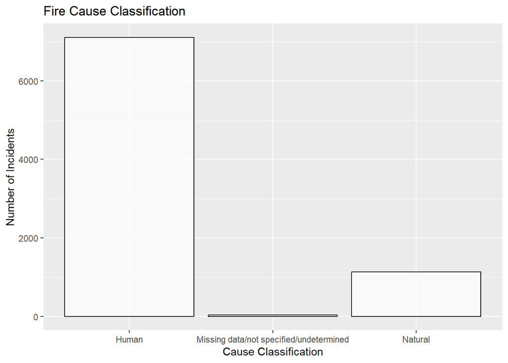

```r
ggplot(fire, aes(x = NWCG_CAUSE_CLASSIFICATION)) +
  geom_bar(col = "black", fill = "white", alpha = 0.7) +
  labs(title = "Fire Cause Classification",
       x = "Cause Classification",
       y = "Number of Incidents")
```

# Frequency count of causes

```r
general_cause_counts <- table(fire$NWCG_GENERAL_CAUSE)
general_cause_counts <- sort(general_cause_counts, decreasing = TRUE)
general_cause_counts
```

```
##
##                    Debris and open burning
##                                       2476
##    Missing data/not specified/undetermined
##                                       1820
##                         Arson/incendiarism
##                                       1494
##                  Equipment and vehicle use
##                                        914
##                  Misuse of fire by a minor
##                                        446
##                                    Natural
##                                        395
##                                    Smoking
##                                        385
##                    Recreation and ceremony
##                                        158
##        Railroad operations and maintenance
##                                        155
## Power generation/transmission/distribution
##                                         27
##                                  Fireworks
##                                          4
##                Firearms and explosives use
##                                          1
##                               Other causes
##                                          1
```

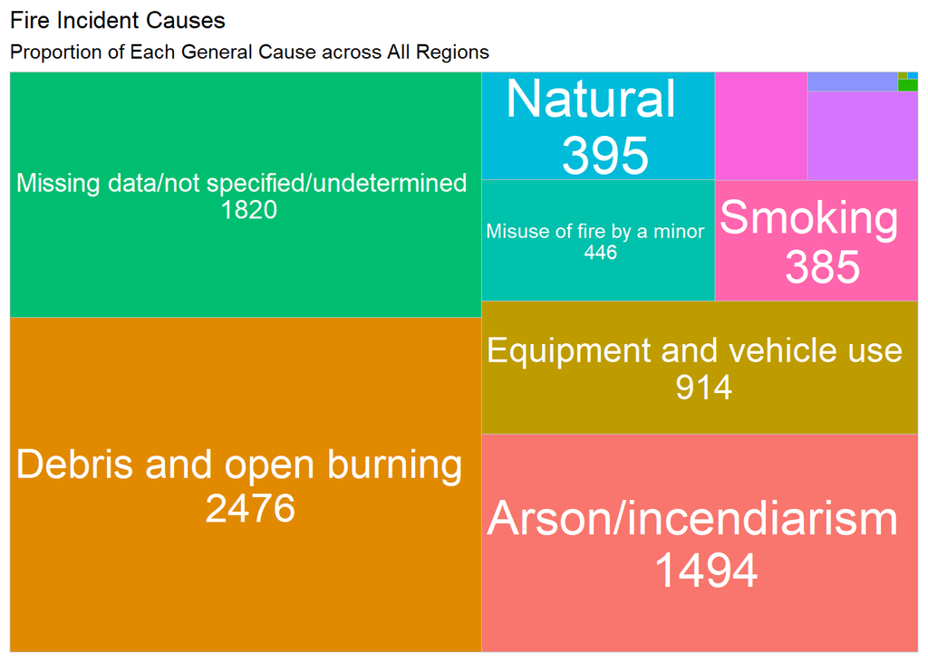

```r
fire_cause_summary <- as.data.frame(table(fire$NWCG_GENERAL_CAUSE))
colnames(fire_cause_summary) <- c("Cause", "Count")
ggplot(fire_cause_summary, aes(area = Count, fill = Cause, label = paste(Cause, "\n", Count))) +
  geom_treemap() +
  geom_treemap_text(colour = "white", place = "centre", grow = TRUE) +
  labs(title = "Fire Incident Causes",
       subtitle = "Proportion of Each General Cause across All Regions") +
  theme(legend.position = "none")
```

# Segregation based on states

```r
table(fire$STATE)
```

```
##
##   DC   MD   VA
##   52 2148 6076
```

# Bar chart on fire incidences in States.

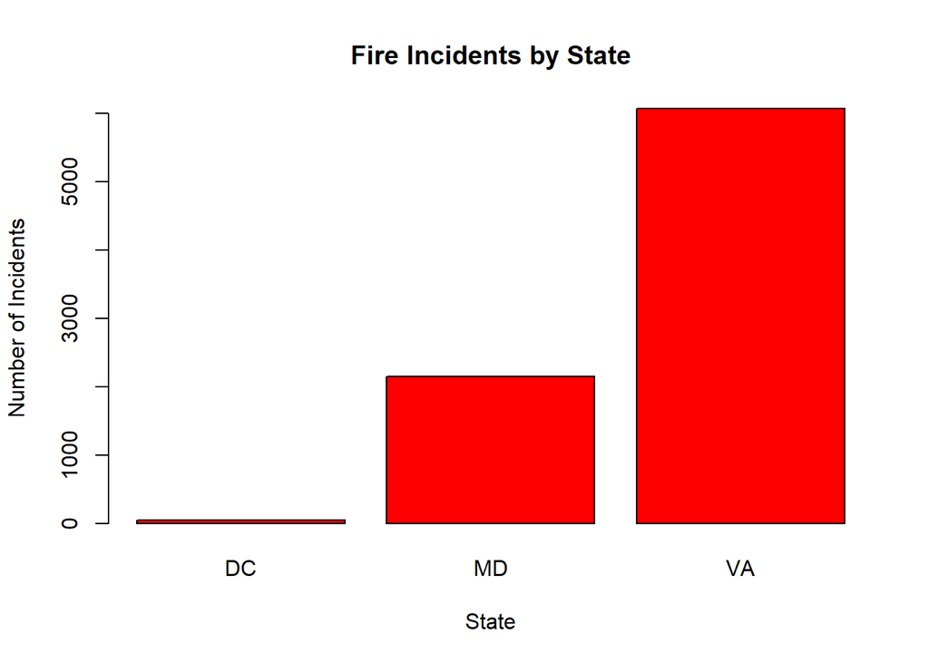

```r
state_counts <- table(fire$STATE)
barplot(state_counts,
        main = "Fire Incidents by State",
        xlab = "State",
        ylab = "Number of Incidents",
        col = "red")
```

# Classification of urban and rural counties in DC,MD and VA.

```r
urban_counties <- c("Washington, D.C.",
                    "Montgomery County", "Prince George's County", "Baltimore City",
                    "Anne Arundel County", "Howard County",
                    "Fairfax County", "Arlington County", "Virginia Beach City",
                    "Chesterfield County", "Henrico County", "Loudoun County")

rural_counties <- c("Garrett County", "Allegany County", "Washington County",
                    "Caroline County", "Somerset County", "Dorchester County",
                    "Bath County", "Highland County", "Scott County",
                    "Lee County", "Tazewell County", "Wise County")

# Create new Area Type variable
fire$AREA_TYPE <- ifelse(fire$FIPS_NAME %in% urban_counties, "Urban", "Rural")

# View distribution
table(fire$AREA_TYPE)
```

```
##
## Rural Urban
##  7969   307
```

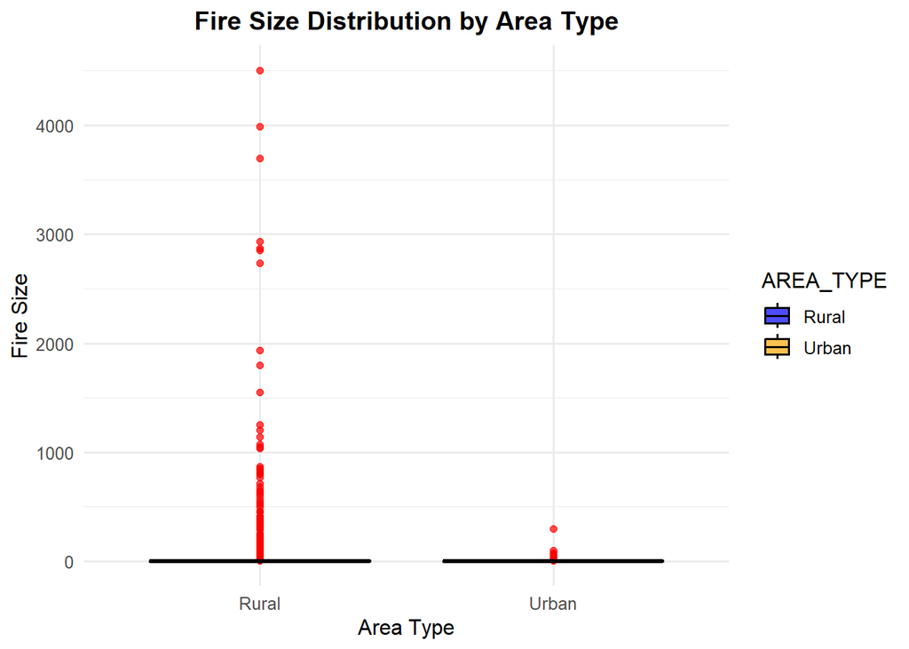

```r
ggplot(fire, aes(x = AREA_TYPE, y = FIRE_SIZE, fill = AREA_TYPE)) +
  geom_boxplot(alpha = 0.7, color = "black", outlier.colour = "red") +
  labs(title = "Fire Size Distribution by Area Type",
       x = "Area Type",
       y = "Fire Size") +
  scale_fill_manual(values = c("blue", "orange", "black")) +
  theme_minimal(base_size = 12) +
  theme(plot.title = element_text(hjust = 0.5, face = "bold"),
        axis.text.x = element_text(angle = 0, hjust = 0.5))
```

# Frequency table of causes by area type

```r
cause_table <- table(fire$AREA_TYPE, fire$NWCG_GENERAL_CAUSE)
cause_table
```

```
##
##         Arson/incendiarism Debris and open burning Equipment and vehicle use
##   Rural               1435                    2452                       884
##   Urban                 59                      24                        30
##
##         Firearms and explosives use Fireworks
##   Rural                           1         4
##   Urban                           0         0
##
##         Missing data/not specified/undetermined Misuse of fire by a minor
##   Rural                                    1722                       411
##   Urban                                      98                        35
##
##         Natural Other causes Power generation/transmission/distribution
##   Rural     384            1                                         26
##   Urban      11            0                                          1
##
##         Railroad operations and maintenance Recreation and ceremony Smoking
##   Rural                                 144                     146     359
##   Urban                                  11                      12      26
```

# Distibution of fire cause by area type

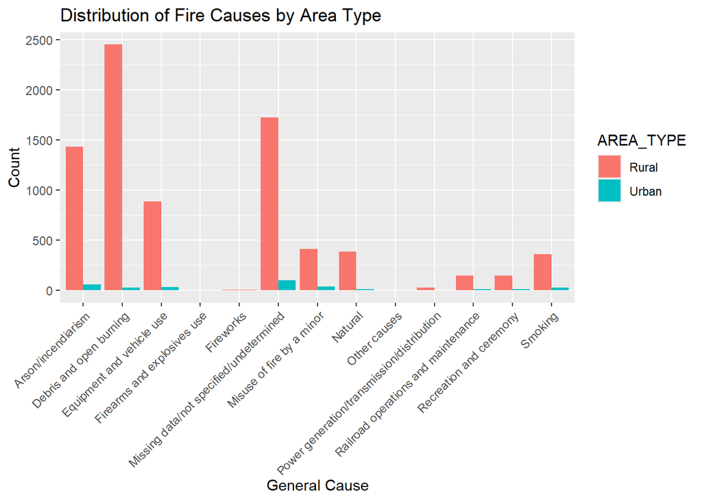

```r
ggplot(data = fire, aes(x = NWCG_GENERAL_CAUSE, fill = AREA_TYPE)) +
  geom_bar(position = "dodge") +
  labs(title = "Distribution of Fire Causes by Area Type",
       x = "General Cause", y = "Count") +
  theme(axis.text.x = element_text(angle = 45, hjust = 1))
```

# Identify risk factors associated with different areas.

```r
risk_factor <- chisq.test(table(fire$AREA_TYPE, fire$NWCG_GENERAL_CAUSE))
risk_factor
```

```
##
##  Pearson's Chi-squared test
##
## data:  table(fire$AREA_TYPE, fire$NWCG_GENERAL_CAUSE)
## X-squared = 111.25, df = 12, p-value < 2.2e-16
```

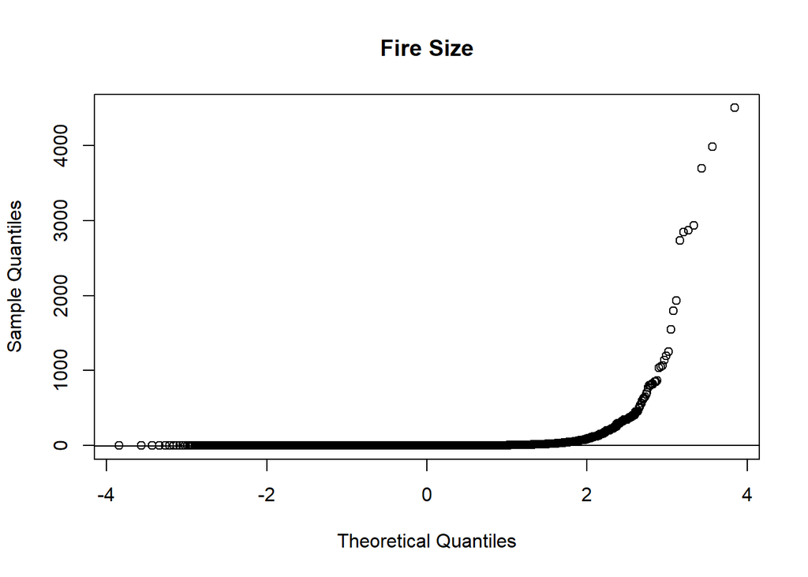

```r
qqnorm(fire$FIRE_SIZE, main = "Fire Size") ## Assess whether the distribution of fire sizes follows a normal distribution.
qqline(fire$FIRE_SIZE)
```